# How students’ social-economic status and type of school affect their math scores

Aimee Trang Thuy Nguyen

A large number of Australian parents pay high fees for schools because they believe that this helps their children with achieving better results. The parents who can afford high fees are usually also from a high socio-economic class. Do children in expensive schools perform better because of their socio-economic class, or because of better schools? In this analysis, we will look at students’ math scores and how this is related to their socio-economic status and the type of school.

**##1**

We have nested levels in this data. Because a student can only study in one school (student nested in school) and a school can only be either private or public (school nested in Type of school).

**##2**

```
## # A tibble: 2,174 × 7
##    School Type    Size Status   Math mStatus cStatus
##    <fct>  <chr>  <dbl>  <dbl>  <dbl>   <dbl>   <dbl>
##  1 1      public   842 -0.228 15.9    0.0256 -0.254
##  2 1      public   842 -0.208  1.86   0.0256 -0.234
##  3 1      public   842  0.532 -2.83   0.0256  0.506
##  4 1      public   842  0.662  2.12   0.0256  0.636
##  5 1      public   842 -0.228  6.76   0.0256 -0.254
##  6 1      public   842 -1.08   0.725  0.0256 -1.10
##  7 1      public   842 -1.03   0.836  0.0256 -1.05
##  8 1      public   842  0.242  6.79   0.0256  0.216
##  9 1      public   842 -0.048  8.45   0.0256 -0.0736
## 10 1      public   842  1.46   4.19   0.0256  1.44
## # ℹ 2,164 more rows
```

**##3**

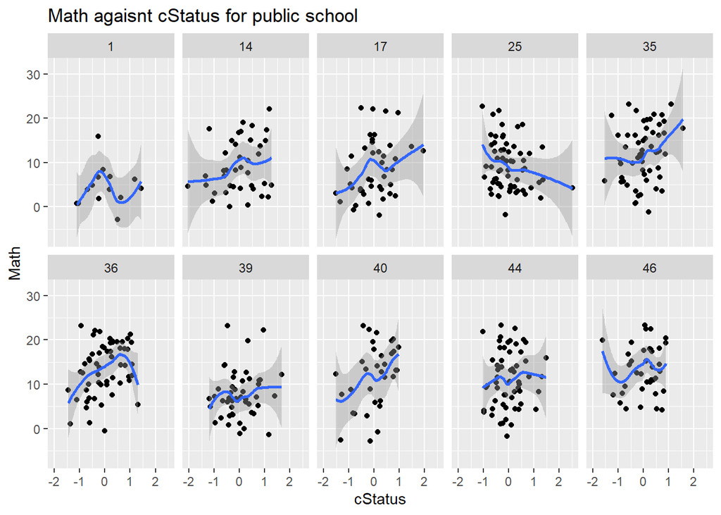

[figure not shown]

Overall, for both type of school, the higher the social-economic status of their parents, the students tend to achieve higher Math score. However, there is also an exception, for example, **public** school number *25* graph shows the opposite effect where student with higher family social-economic status tend to get lower Math grade.

The Math scores in both types of school also range from under 0 to below 25. It also seems like there are more students with lower family social-economic status study in **public** schools than **private** schools because the points skewed to the left.

**##4**

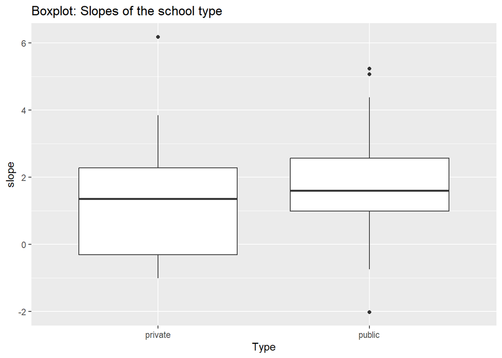

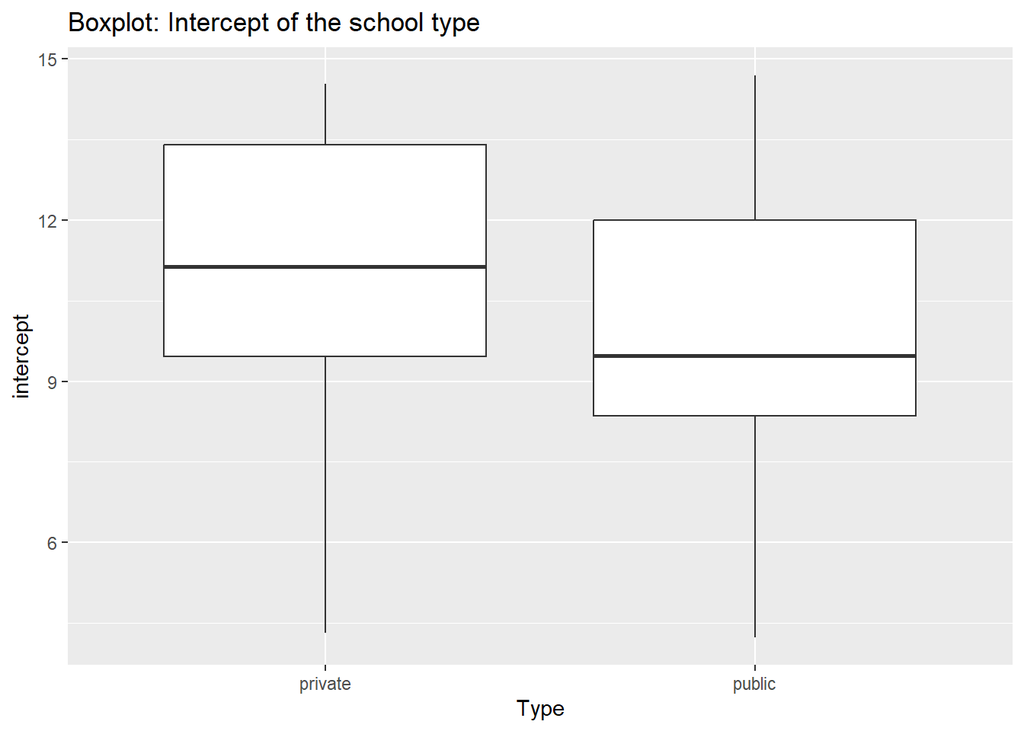

Looking at the boxplot plot for the *slope*, it is obvious that the effect of social-economic status to the Math score is stronger for **public** school than **private** school (this is illustrated by the higher median in the boxplot). The effect of social-economic status is also more varied for **private** school than **public** school (due to larger range). Some outliers also appeared for both type of school. For example, an outlier from **private** school type which has the slope of more than *6*, this indicates that the difference in Math scores in this school is significantly affected by the social-economic status.

According to the *intercept* boxplot, we can see that on average, students in **private** school achieve higher Math scores than students in **public school**. The ranges of the Math score also vary in both school types.

**##5**

```r
me_mod <- lmer(Math ~ mStatus + cStatus + Type + cStatus*Type + (cStatus|School), data = mydf)
```

**##6**

```
## Linear mixed model fit by REML ['lmerMod']
## Formula: Math ~ mStatus + cStatus + Type + cStatus * Type + (cStatus |
##     School)
##    Data: mydf
##
## REML criterion at convergence: 13954
##
## Scaled residuals:
##      Min       1Q   Median       3Q      Max
## -2.71032 -0.74023 -0.01129  0.71450  2.81159
##
## Random effects:
##  Groups   Name        Variance Std.Dev. Corr
##  School   (Intercept)  2.6630  1.6319
##           cStatus      0.6111  0.7817   0.12
##  Residual             34.5769  5.8802
## Number of obs: 2174, groups:  School, 50
##
## Fixed effects:
##                    Estimate Std. Error t value
## (Intercept)         11.5687     0.4146  27.902
## mStatus              4.5119     0.6308   7.152
## cStatus              1.2584     0.3385   3.718
## Typepublic          -0.3064     0.5431  -0.564
## cStatus:Typepublic   0.3705     0.4508   0.822
##
## Correlation of Fixed Effects:
##             (Intr) mStats cStats Typpbl
## mStatus      0.221
## cStatus      0.051  0.000
## Typepublic  -0.689  0.166 -0.039
## cStts:Typpb -0.039 -0.001 -0.751  0.051
```

- On average, 1 value increase in the mean of the social-economic status within school where the student attend, the Math score will be 4.51 points higher, while holding everything else constant.
- On average, **public** school students achieve 0.31 points lower in Math score than **private** school students.
- The Math score of **private** school students will be 1.26 points higher if the social-economic status of their parents increase by 1 value.
- Likewise, The Math score of **public** school students will be 1.62 (1.26 + 0.37) points higher if the social-economic status of their parents increase by 1 value.

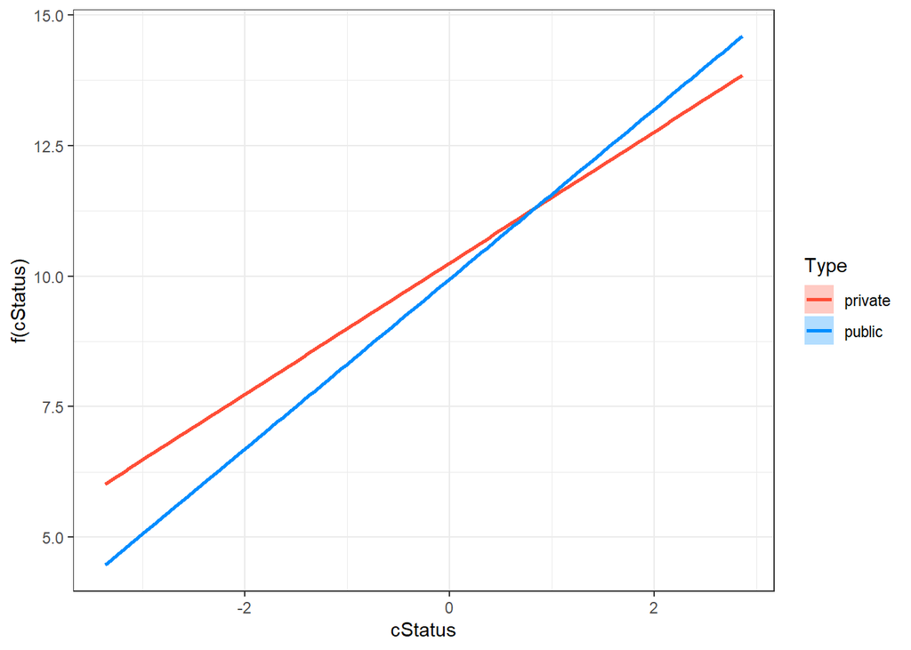

For both type of schools, students whose parents have higher social-economic status tend to achieve higher Math score. With the group of lower social-economic status, it seems that **private** school students achieve higher score than **public** school students. On the other hand, with high social-economic status group, **public** students are more likely to get higher Math score.

**##7**

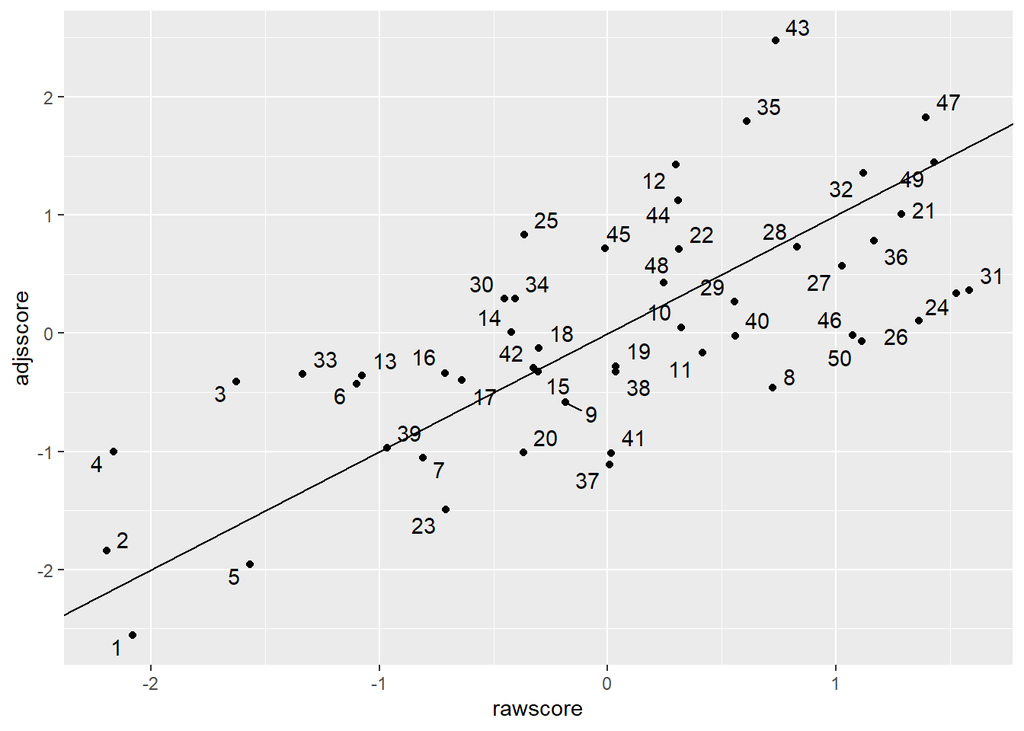

The variability of the intercept across schools is 2.66. So the Math score across schools vary from the average Math score of all schools 1.6 points. School **43** has not too high raw score but is best in adjusted score. On the other hand, school **24** and **31** have high raw scores but their adjusted scores are low.

The variability of the slopes between schools is 0.61. The correlation between slopes and intercepts is only 0.12, which means there is almost no relation between slopes and intercepts.

**##8**

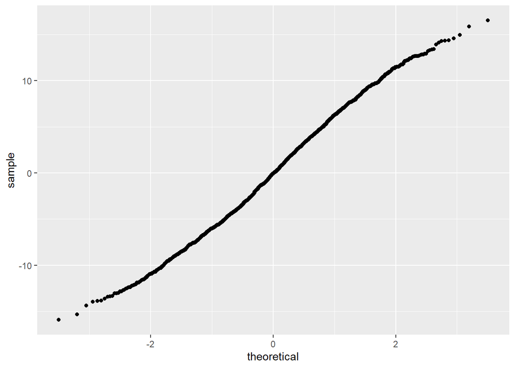

This looks really good with the line nearly lies on 45 degree line. Thus, we can confirm the normality of residuals.

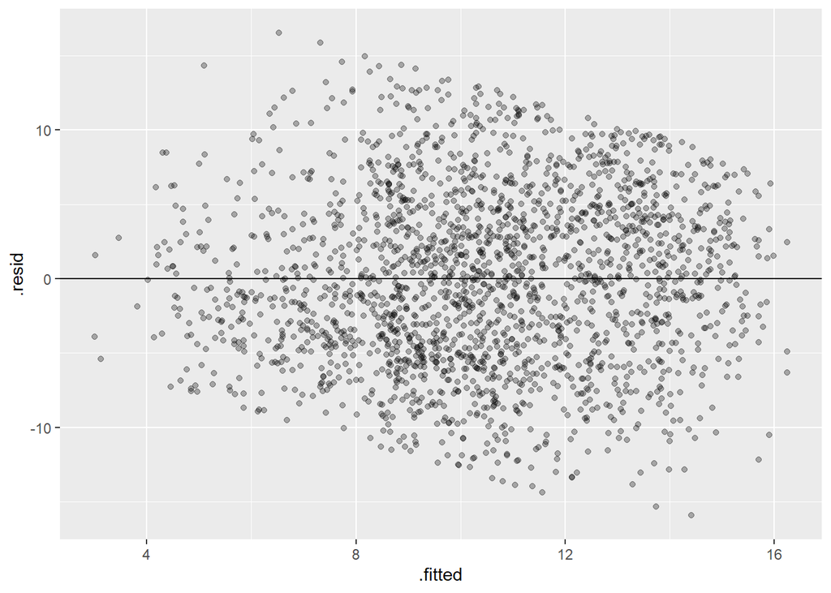

The graph looks kind of like a diamond shape, but overall, all the points scatter around 0 so we can say that residuals are randomly distributed.

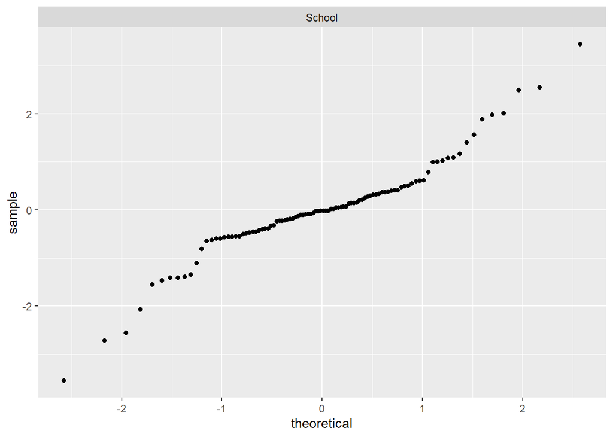

Now we examine the assumption that random effect is normally distributed. Looking at this graph, it somewhat follows 45 degree line but there are some fluctuations at both of the tails.

**##9**

```
## Computing bootstrap confidence intervals ...
```

```
##
## 61 message(s): boundary (singular) fit: see help('isSingular')
## 4 warning(s): Model failed to converge with max|grad| = 0.00210652 (tol = 0.002, component 1) (and others)
```

```
##                          2.5 %     97.5 %
## .sig01              1.18222684  2.0989748
## .sig02             -1.00000000  1.0000000
## .sig03              0.06858617  1.3149246
## .sigma              5.70396360  6.0681362
## (Intercept)        10.69899020 12.4205562
## mStatus             3.26336811  5.7401304
## cStatus             0.61049585  1.8679907
## Typepublic         -1.36642103  0.8055475
## cStatus:Typepublic -0.45379459  1.2945627
```

**##10**

[output not shown]

[output cut: 294 more lines]

[output not shown]

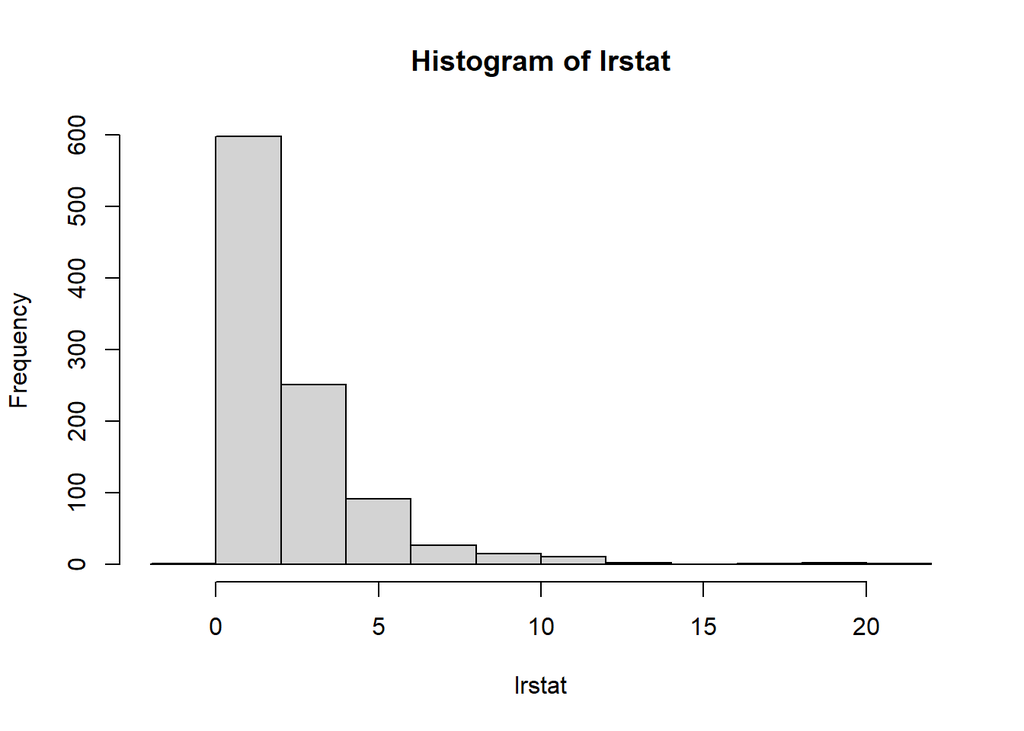

```
## [1] 0.601
```

The actual log-likelihood ratio of the model is in the left tail of the histogram so the probability of not rejecting the null might be large. Next, we check the p-value to confirm the result. It turns out that p-value is much larger than 0.05 so we definitely cannot reject the null. This indicates that there is no mean to include the interaction term **Type:cStatus** and **Type** in the model, the model is better without these two variables. This conclusion is also in line with the finding on question 9 that **Type** variable and the interaction term are not significant.